# CausalImpact Google

```r
summary(impact_temp)
```

```
## Posterior inference {CausalImpact}
##
##                          Average            Cumulative
## Actual                   223691             2236908
## Prediction (s.d.)        287920 (14562)     2879203 (145618)
## 95% CI                   [260031, 316869]   [2600311, 3168692]
##
## Absolute effect (s.d.)   -64229 (14562)     -642295 (145618)
## 95% CI                   [-93178, -36340]   [-931784, -363403]
##
## Relative effect (s.d.)   -22% (4%)          -22% (4%)
## 95% CI                   [-29%, -14%]       [-29%, -14%]
##
## Posterior tail-area probability p:   2e-04
## Posterior prob. of a causal effect:  99.97992%
##
## For more details, type: summary(impact, "report")
```

Now, we check on impacts of Air travel 9 months BEFORE the intervention as a placebo and see that there is, in fact, no significant deviation from the projection over the 9 months. This argues that our model will not project substantial deviations between the counter-factual and actual when no deviation occurs. Essentially suggesting our model is an accurate predictor.

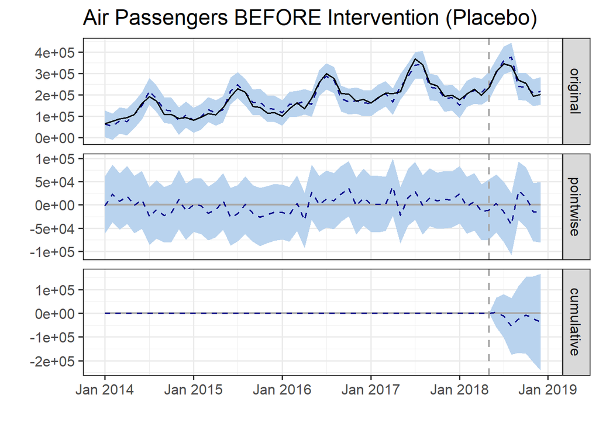

```r
# checking 9 months prior, we see no impact!

complete <- month # Restart the formula

# what is the selected indicator's column?
complete2 <- complete[,7] # change this to pick out your indicator, then just pick your dates
# list of remaining columns
icelandcolumns <- grep('iceland', colnames(complete))
complete <- complete[,-c(icelandcolumns)]

complete <- cbind(complete,complete2)

complete <- complete %>% filter(date > '2013-12-31') %>% filter(date < '2019-12-31') # to do arrivals
#complete <- complete[,-c(2:4)]

complete <- complete[ , colSums(is.na(complete))==0] %>% relocate(visitors_iceland) %>% relocate(date)

temp<- ts(data = complete[-c(1)],
                             start = 2014,
                             end = 2020,
                             frequency = 12) %>% head(-13)
pre.period <- as.yearmon(c("2014-01-01", "2018-05-01"))

post.period <- as.yearmon(c("2018-06-01", "2019-03-01"))

impact_temp <- CausalImpact(temp,pre.period,post.period, model.args=list(niter=5000, nseasons = 12, season.duration = 1))
plot(impact_temp) + ggtitle("Air Passengers BEFORE Intervention (Placebo)")
```

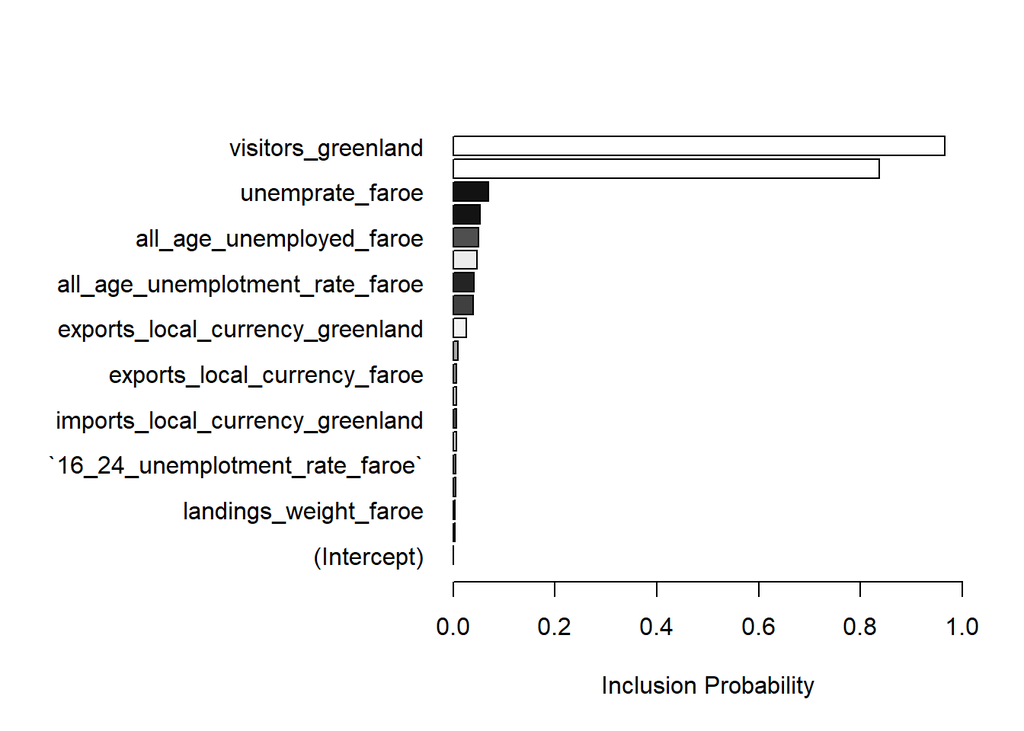

```r
plot(impact_temp$model$bsts.model, "coefficients") # Predictors For Air Passengers
```

```r
summary(impact_temp)
```

```
## Posterior inference {CausalImpact}
##
##                          Average            Cumulative
## Actual                   272895             1910268
## Prediction (s.d.)        278306 (14560)     1948144 (101919)
## 95% CI                   [249120, 307374]   [1743842, 2151617]
##
## Absolute effect (s.d.)   -5411 (14560)      -37876 (101919)
## 95% CI                   [-34478, 23775]    [-241349, 166426]
##
## Relative effect (s.d.)   -1.6% (5.2%)       -1.6% (5.2%)
## 95% CI                   [-11%, 9.5%]       [-11%, 9.5%]
##
## Posterior tail-area probability p:   0.35555
## Posterior prob. of a causal effect:  64%
##
## For more details, type: summary(impact, "report")
```

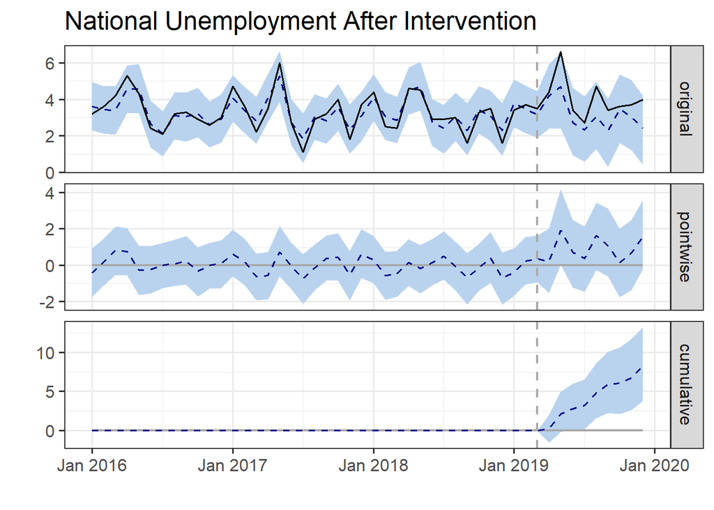

```r
complete <- month # Restart the formula

# what is the selected indicator's column?
complete2 <- complete[,4] # change this to pick out your indicator, then just pick your dates

# list of remaining columns
icelandcolumns <- grep('iceland', colnames(complete))
complete <- complete[,-c(icelandcolumns)]

complete <- cbind(complete,complete2)

complete <- complete %>% filter(date >= '2016-01-01') %>% filter(date < '2019-12-31') # to do arrivals

complete <- complete[ , colSums(is.na(complete))==0] %>% relocate(unemprate_iceland) %>% relocate(date)

impact_temp <- ts(data = complete[-c(1)],
                             start = 2016,
                             end = 2020,
                             frequency = 12) %>% head(-1)
pre.period <- as.yearmon(c("2016-01-01", "2019-03-01"))

post.period <- as.yearmon(c("2019-04-01", "2020-01-01"))

impact_temp <- CausalImpact(impact_temp,pre.period, post.period, model.args=list(niter=5000, nseasons = 12, season.duration = 1))
plot(impact_temp) + ggtitle("National Unemployment After Intervention")
```

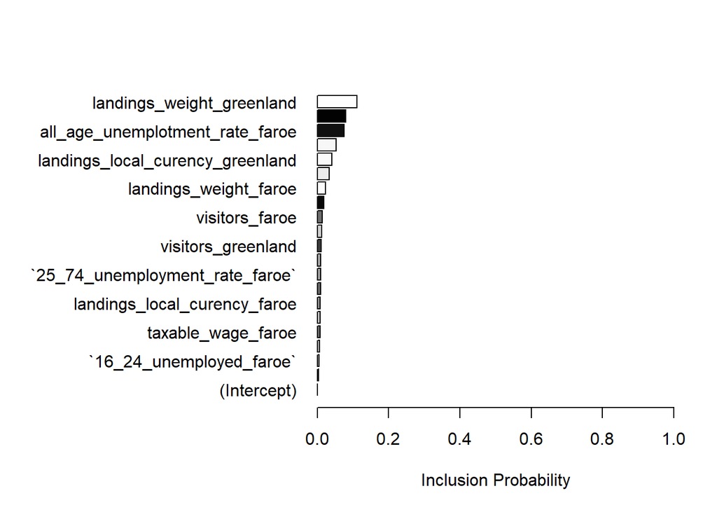

```r
plot(impact_temp$model$bsts.model, "coefficients")  # Predictors For Unnemployment
```

```r
summary(impact_temp)
```

```
## Posterior inference {CausalImpact}
##
##                          Average       Cumulative
## Actual                   4.1           36.5
## Prediction (s.d.)        3.1 (0.26)    28.2 (2.34)
## 95% CI                   [2.6, 3.6]    [23.3, 32.7]
##
## Absolute effect (s.d.)   0.92 (0.26)   8.29 (2.34)
## 95% CI                   [0.43, 1.5]   [3.84, 13.2]
##
## Relative effect (s.d.)   30% (11%)     30% (11%)
## 95% CI                   [12%, 57%]    [12%, 57%]
##
## Posterior tail-area probability p:   4e-04
## Posterior prob. of a causal effect:  99.96%
##
## For more details, type: summary(impact, "report")
```

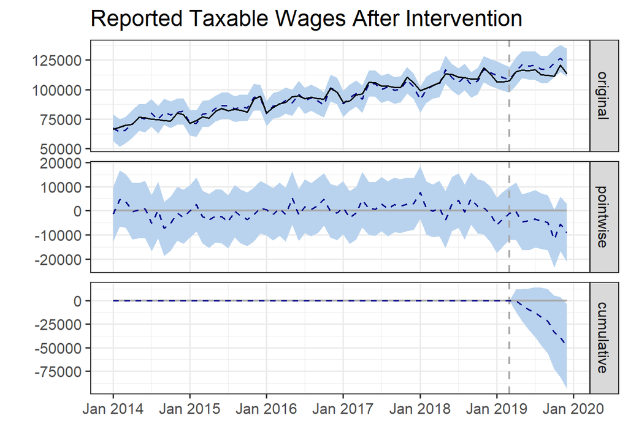

```r
complete <- month # Restart the formula

# what is the selected indicator's column?
complete2 <- complete[,10] # change this to pick out your indicator, then just pick your dates

# list of remaining columns
icelandcolumns <- grep('iceland', colnames(complete))
complete <- complete[,-c(icelandcolumns)]

complete <- cbind(complete,complete2)

complete <- complete %>% filter(date > '2013-12-31') %>% filter(date < '2019-12-31') # to do arrivals

complete <- complete[ , colSums(is.na(complete))==0] %>% relocate(taxable_wage_iceland) %>% relocate(date)

impact_temp <- ts(data = complete[-c(1)],
                             start = 2014,
                             end = 2020,
                             frequency = 12) %>% head(-1)
pre.period <- as.yearmon(c("2014-01-01", "2019-03-01"))

post.period <- as.yearmon(c("2019-04-01", "2019-12-31"))

impact_temp <- CausalImpact(impact_temp,pre.period, post.period, model.args=list(niter=5000, nseasons = 12, season.duration = 1))
plot(impact_temp) + ggtitle("Reported Taxable Wages After Intervention")
```

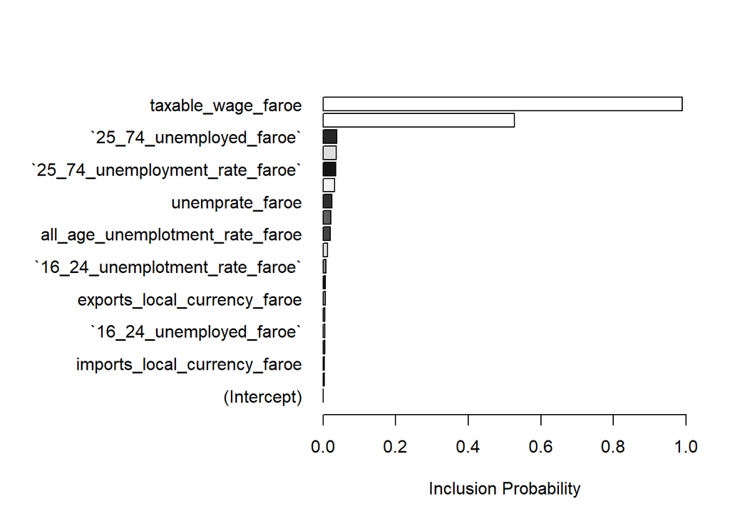

```r
plot(impact_temp$model$bsts.model, "coefficients") # predictors for Taxable Wages
```

```r
summary(impact_temp)
```

```
## Posterior inference {CausalImpact}
##
##                          Average            Cumulative
## Actual                   114985             1034865
## Prediction (s.d.)        120376 (2518)      1083382 (22659)
## 95% CI                   [115405, 125378]   [1038645, 1128400]
##
## Absolute effect (s.d.)   -5391 (2518)       -48517 (22659)
## 95% CI                   [-10393, -420]     [-93535, -3780]
##
## Relative effect (s.d.)   -4.4% (2%)         -4.4% (2%)
## 95% CI                   [-8.3%, -0.36%]    [-8.3%, -0.36%]
##
## Posterior tail-area probability p:   0.01907
## Posterior prob. of a causal effect:  98.093%
##
## For more details, type: summary(impact, "report")
```

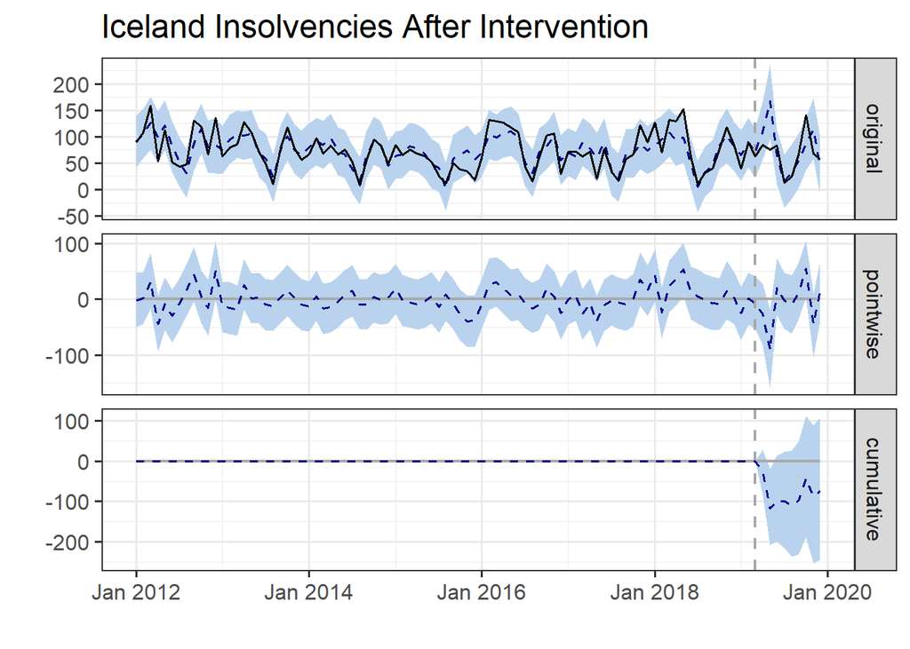

```r
complete <- month # Restart the formula
# what is the selected indicator's column?
complete2 <- complete[,43] # change this to pick out your indicator, then just pick your dates

# list of remaining columns
icelandcolumns <- grep('iceland', colnames(complete))
complete <- complete[,-c(icelandcolumns)]

complete <- cbind(complete,complete2)

complete <- complete %>% filter(date > '2011-12-31') %>% filter(date < '2019-12-31') # to do arrivals

complete <- complete[ , colSums(is.na(complete))==0] %>% relocate(insolvencies_total_iceland) %>% relocate(date)

impact_temp <- ts(data = complete[-c(1)],
                             start = 2012,
                             end = 2020,
                             frequency = 12) %>% head(-1)
pre.period <- as.yearmon(c("2012-01-01", "2019-03-01"))

post.period <- as.yearmon(c("2019-04-01", "2019-12-31"))

impact_temp <- CausalImpact(impact_temp,pre.period, post.period, model.args=list(niter=5000, nseasons = 12, season.duration = 1))
plot(impact_temp) + ggtitle("Iceland Insolvencies After Intervention")
```

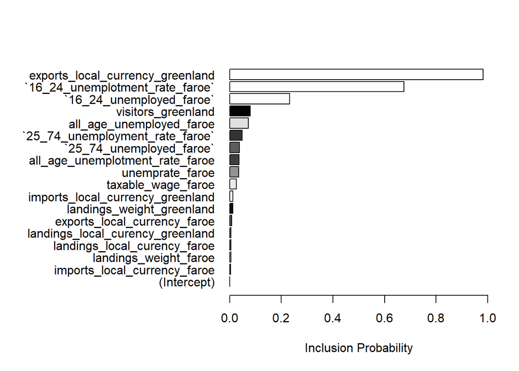

```r
plot(impact_temp$model$bsts.model, "coefficients") # predictors For Insolvencies
```

```r
summary(impact_temp)
```

```
## Posterior inference {CausalImpact}
##
##                          Average       Cumulative
## Actual                   68            614
## Prediction (s.d.)        76 (10)       687 (90)
## 95% CI                   [56, 95]      [506, 859]
##
## Absolute effect (s.d.)   -8.2 (10)     -73.4 (90)
## 95% CI                   [-27, 12]     [-245, 108]
##
## Relative effect (s.d.)   -8.9% (13%)   -8.9% (13%)
## 95% CI                   [-29%, 21%]   [-29%, 21%]
##
## Posterior tail-area probability p:   0.20689
## Posterior prob. of a causal effect:  79%
##
## For more details, type: summary(impact, "report")
```

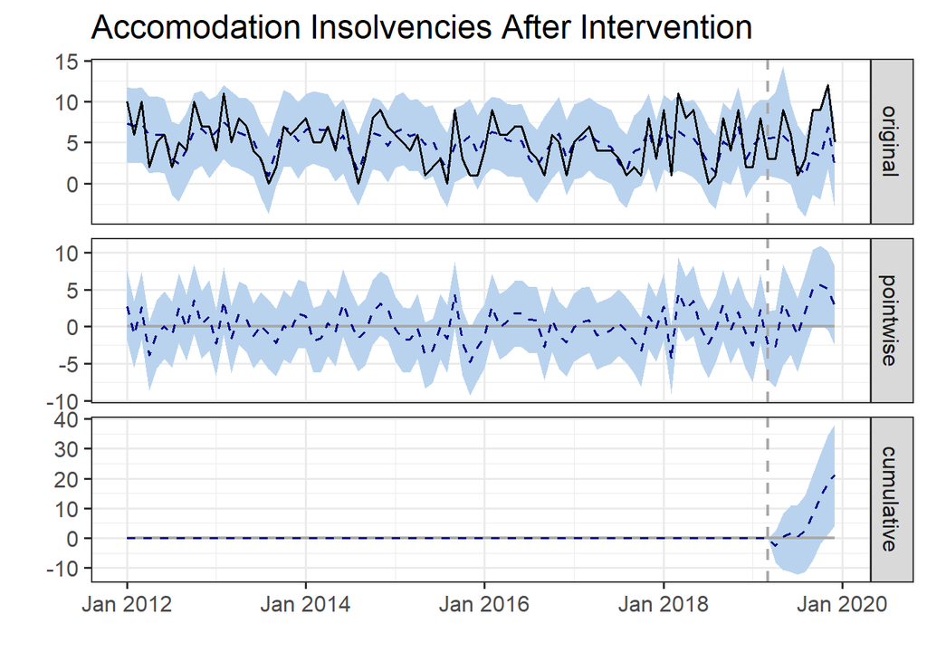

```r
complete <- month # Restart the formula
# what is the selected indicator's column?
complete2 <- complete[,49] # change this to pick out your indicator, then just pick your dates
# list of remaining columns
icelandcolumns <- grep('iceland', colnames(complete))
complete <- complete[,-c(icelandcolumns)]

complete <- cbind(complete,complete2)

complete <- complete %>% filter(date > '2011-12-31') %>% filter(date < '2019-12-31') # to do arrivals

complete <- complete[ , colSums(is.na(complete))==0] %>% relocate(insolvencies_accomodation_iceland) %>% relocate(date)

impact_temp <- ts(data = complete[-c(1)],
                             start = 2012,
                             end = 2020,
                             frequency = 12) %>% head(-1)
pre.period <- as.yearmon(c("2012-01-01", "2019-03-01"))

post.period <- as.yearmon(c("2019-04-01", "2019-12-31"))

impact_temp <- CausalImpact(impact_temp,pre.period, post.period, model.args=list(niter=5000, nseasons = 12, season.duration = 1))
plot(impact_temp) + ggtitle("Accomodation Insolvencies After Intervention")
```

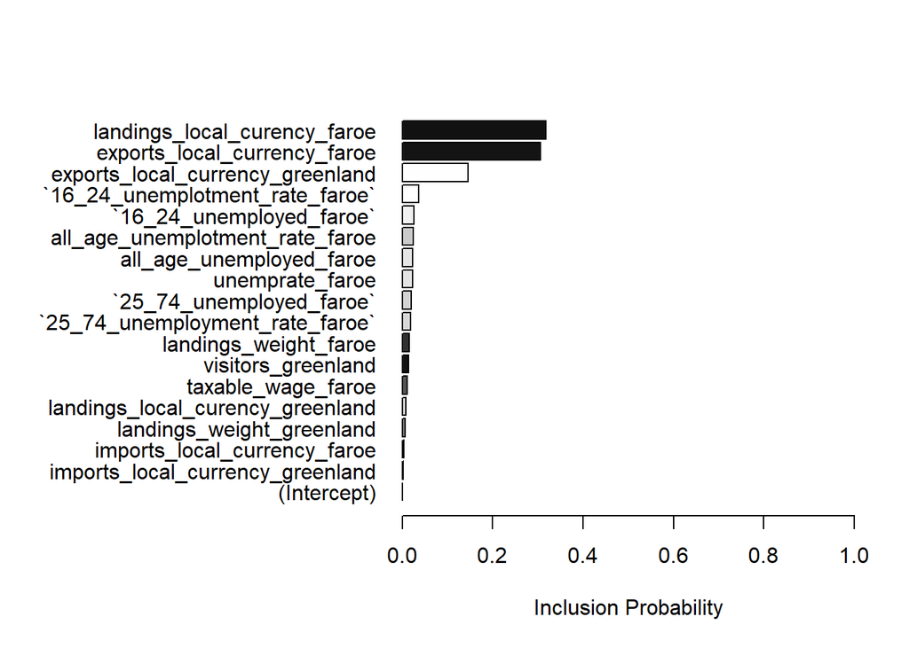

```r
plot(impact_temp$model$bsts.model, "coefficients") # Predictors for Accomodation Insolvencies
```

```r
summary(impact_temp)
```

```
## Posterior inference {CausalImpact}
##
##                          Average       Cumulative
## Actual                   6.3           57.0
## Prediction (s.d.)        4 (0.97)      36 (8.77)
## 95% CI                   [2.1, 5.9]    [18.9, 52.8]
##
## Absolute effect (s.d.)   2.4 (0.97)    21.2 (8.77)
## 95% CI                   [0.47, 4.2]   [4.20, 38.1]
##
## Relative effect (s.d.)   71% (53%)     71% (53%)
## 95% CI                   [8%, 202%]    [8%, 202%]
##
## Posterior tail-area probability p:   0.0078
## Posterior prob. of a causal effect:  99.22%
##
## For more details, type: summary(impact, "report")
```

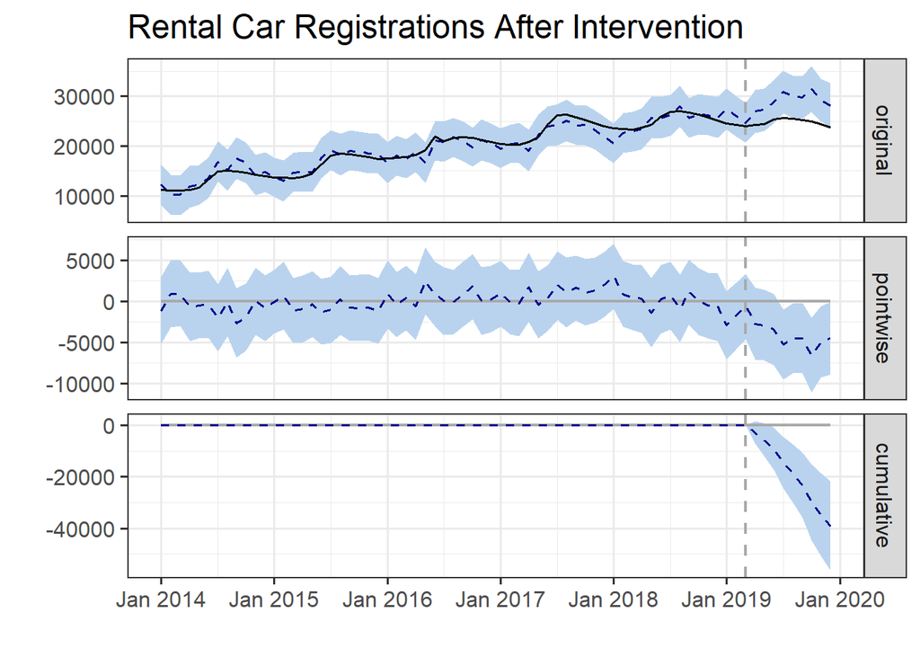

```r
complete <- month # Restart the formula

# what is the selected indicator's column?
complete2 <- complete[,37] # change this to pick out your indicator, then just pick your dates

# list of remaining columns
icelandcolumns <- grep('iceland', colnames(complete))
complete <- complete[,-c(icelandcolumns)]

complete <- cbind(complete,complete2)

complete <- complete %>% filter(date > '2013-12-31') %>% filter(date < '2019-12-31') # to do arrivals

complete <- complete[ , colSums(is.na(complete))==0] %>% relocate(rental_cars_iceland) %>% relocate(date)

impact_temp <- ts(data = complete[-c(1)],
                             start = 2014,
                             end = 2020,
                             frequency = 12) %>% head(-1) # need this on ALL of these


pre.period <- as.yearmon(c("2014-01-01", "2019-03-01"))

post.period <- as.yearmon(c("2019-04-01", "2019-12-31"))

impact_temp <- CausalImpact(impact_temp,pre.period, post.period, model.args=list(niter=5000, nseasons = 12, season.duration = 1))
plot(impact_temp) + ggtitle("Rental Car Registrations After Intervention")
```

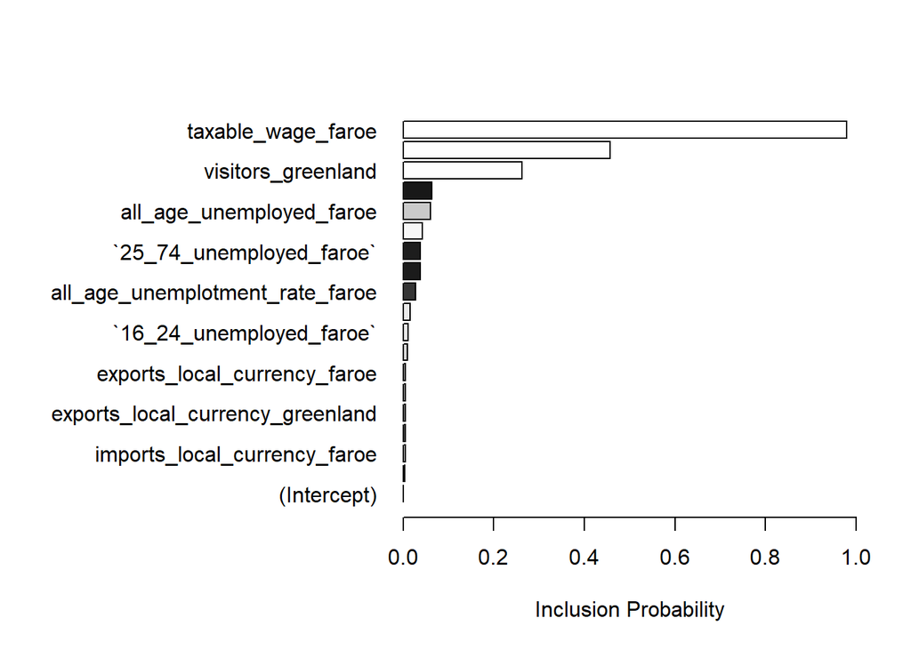

```r
plot(impact_temp$model$bsts.model, "coefficients") # predictors for Rental Car Registrations
```

```r
summary(impact_temp)
```

```
## Posterior inference {CausalImpact}
##
##                          Average          Cumulative
## Actual                   24846            223613
## Prediction (s.d.)        29206 (984)      262854 (8855)
## 95% CI                   [27251, 31104]   [245261, 279937]
##
## Absolute effect (s.d.)   -4360 (984)      -39241 (8855)
## 95% CI                   [-6258, -2405]   [-56324, -21648]
##
## Relative effect (s.d.)   -15% (2.9%)      -15% (2.9%)
## 95% CI                   [-20%, -8.8%]    [-20%, -8.8%]
##
## Posterior tail-area probability p:   2e-04
## Posterior prob. of a causal effect:  99.97996%
##
## For more details, type: summary(impact, "report")
```

As a second Placebo Check, I am investigating a sector that should be exogenous to shocks of the airline industry. I use total weight of fish landed in Iceland. Again, we see no significant deviation from our projection.

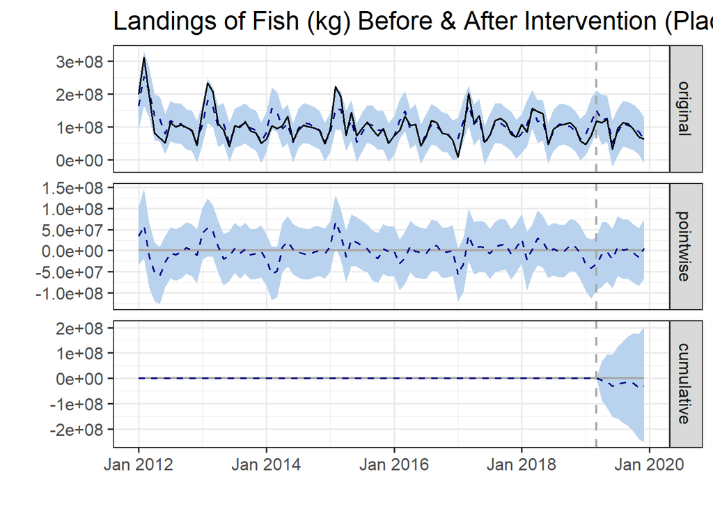

```r
complete <- month # Restart the formula
# what is the selected indicator's column?
complete2 <- complete[,61] # change this to pick out your indicator, then just pick your dates

# list of remaining columns
icelandcolumns <- grep('iceland', colnames(complete))
complete <- complete[,-c(icelandcolumns)]

complete <- cbind(complete,complete2)

complete <- complete %>% filter(date > '2011-12-31') %>% filter(date < '2019-12-31') # to do arrivals

complete <- complete[ , colSums(is.na(complete))==0] %>% relocate(landings_weight_iceland) %>% relocate(date)

impact_temp <- ts(data = complete[-c(1)],
                             start = 2012,
                             end = 2020,
                             frequency = 12) %>% head(-1) # need this on ALL of these


pre.period <- as.yearmon(c("2012-01-01", "2019-03-01"))

post.period <- as.yearmon(c("2019-04-01", "2019-12-31"))

impact_temp <- CausalImpact(impact_temp,pre.period, post.period, model.args=list(niter=5000, nseasons = 12, season.duration = 1))
plot(impact_temp) + ggtitle("Landings of Fish (kg) Before & After Intervention (Placebo)")
```

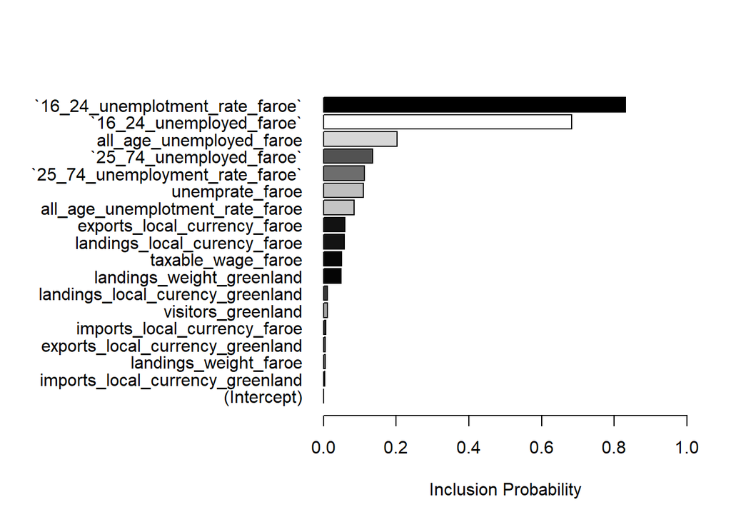

```r
plot(impact_temp$model$bsts.model, "coefficients") # predictors for Fish Catch Weight in Iceland
```

```r
summary(impact_temp)
```

```
## Posterior inference {CausalImpact}
##
##                          Average               Cumulative
## Actual                   9.0e+07               8.1e+08
## Prediction (s.d.)        9.3e+07 (1.3e+07)     8.4e+08 (1.2e+08)
## 95% CI                   [6.7e+07, 1.2e+08]    [6.0e+08, 1.1e+09]
##
## Absolute effect (s.d.)   -3.5e+06 (1.3e+07)    -3.2e+07 (1.2e+08)
## 95% CI                   [-2.8e+07, 2.3e+07]   [-2.5e+08, 2.1e+08]
##
## Relative effect (s.d.)   -1.9% (15%)           -1.9% (15%)
## 95% CI                   [-24%, 34%]           [-24%, 34%]
##
## Posterior tail-area probability p:   0.37879
## Posterior prob. of a causal effect:  62%
##
## For more details, type: summary(impact, "report")
```

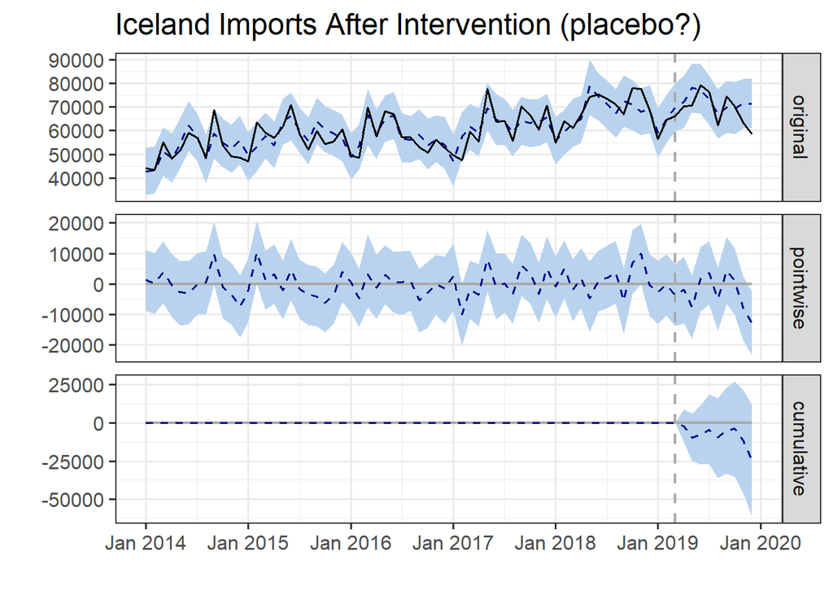

```r
complete <- month # Restart the formula
# what is the selected indicator's column?
complete2 <- complete[,58] # change this to pick out your indicator, then just pick your dates

# list of remaining columns
icelandcolumns <- grep('iceland', colnames(complete))
complete <- complete[,-c(icelandcolumns)]

complete <- cbind(complete,complete2)

complete <- complete %>% filter(date > '2013-12-31') %>% filter(date < '2019-12-31') # to do arrivals

complete <- complete[ , colSums(is.na(complete))==0] %>% relocate(imports_local_currency_iceland) %>% relocate(date)

impact_temp <- ts(data = complete[-c(1)],
                             start = 2014,
                             end = 2020,
                             frequency = 12) %>% head(-1) # need this on ALL of these


pre.period <- as.yearmon(c("2014-01-01", "2019-03-01"))

post.period <- as.yearmon(c("2019-04-01", "2019-12-31"))

impact_temp <- CausalImpact(impact_temp,pre.period, post.period, model.args=list(niter=5000, nseasons = 12, season.duration = 1))
plot(impact_temp) + ggtitle("Iceland Imports After Intervention (placebo?)")
```

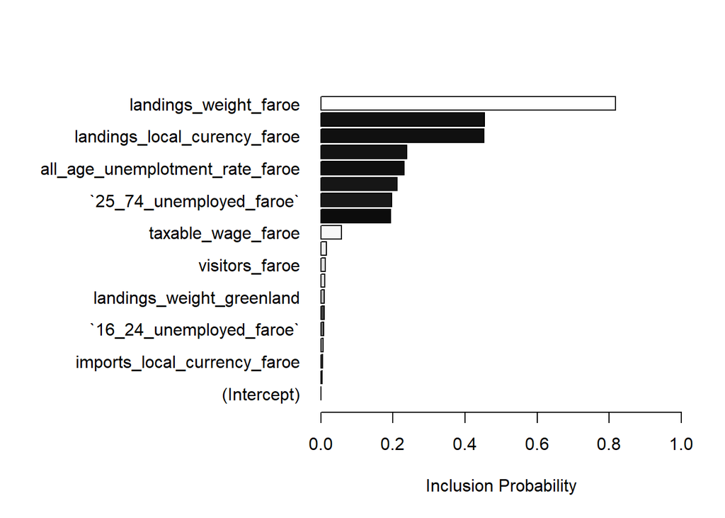

```r
plot(impact_temp$model$bsts.model, "coefficients") # predictors for Icelandic Imports
```

```r
summary(impact_temp)
```

```
## Posterior inference {CausalImpact}
##
##                          Average          Cumulative
## Actual                   69432            624889
## Prediction (s.d.)        72169 (2061)     649520 (18548)
## 95% CI                   [68144, 76227]   [613296, 686041]
##
## Absolute effect (s.d.)   -2737 (2061)     -24631 (18548)
## 95% CI                   [-6795, 1288]    [-61151, 11593]
##
## Relative effect (s.d.)   -3.7% (2.8%)     -3.7% (2.8%)
## 95% CI                   [-8.9%, 1.9%]    [-8.9%, 1.9%]
##
## Posterior tail-area probability p:   0.09233
## Posterior prob. of a causal effect:  91%
##
## For more details, type: summary(impact, "report")
```

```r
# less compelling, but I think it makes sense - more connected to local markets
# another thought - is imports the same as external tourism? decreasing outward flows of tourism?
```

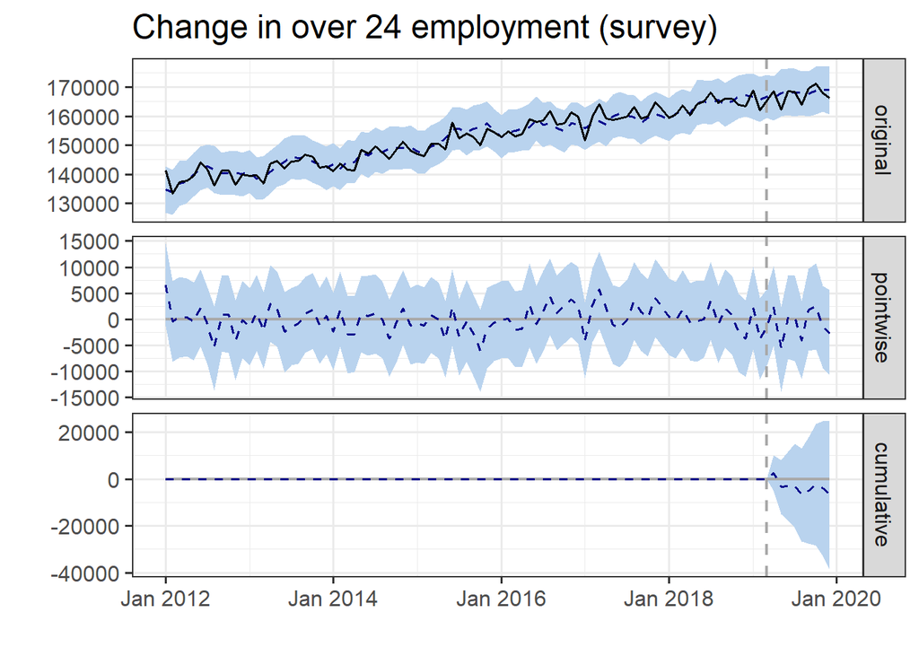

```r
complete <- month # Restart the formula
# what is the selected indicator's column?
complete2 <- complete[,100] # change this to pick out your indicator, then just pick your dates
colnames(complete2) <- c("over_24_employed_iceland")
# list of remaining columns
icelandcolumns <- grep('iceland', colnames(complete))
complete <- complete[,-c(icelandcolumns)]

complete <- cbind(complete,complete2)

complete <- complete %>% filter(date > '2011-12-31') %>% filter(date < '2019-12-31') # to do arrivals
complete <- complete[ , colSums(is.na(complete))==0] %>% relocate(over_24_employed_iceland) %>% relocate(date)

impact_temp <- ts(data = complete[-c(1)],
                             start = 2012,
                             end = 2020,
                             frequency = 12) %>% head(-1) # need this on ALL of these


pre.period <- as.yearmon(c("2012-01-01", "2019-03-01"))

post.period <- as.yearmon(c("2019-04-01", "2019-12-31"))

impact_temp<- CausalImpact(impact_temp,pre.period, post.period, model.args=list(niter=5000, nseasons = 12, season.duration = 1))
plot(impact_temp) + ggtitle("Change in over 24 employment (survey)")
```

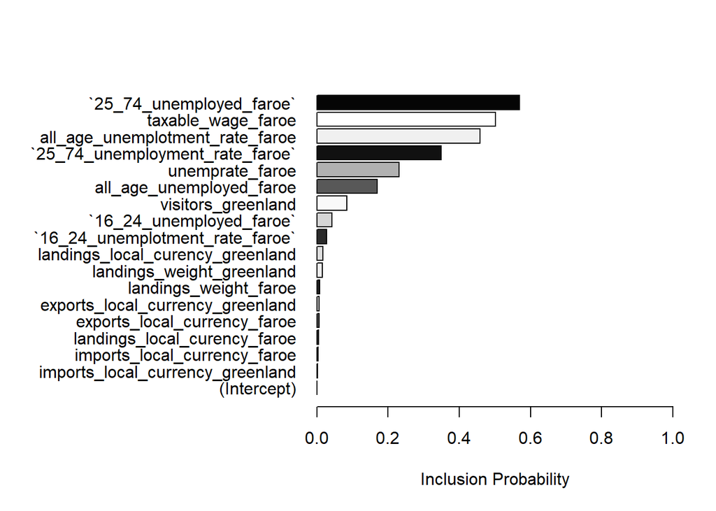

```r
plot(impact_temp$model$bsts.model, "coefficients") # predictors for over 24 employment
```

```r
summary(impact_temp)
```

```
## Posterior inference {CausalImpact}
##
##                          Average            Cumulative
## Actual                   167400             1506600
## Prediction (s.d.)        168135 (1825)      1513211 (16422)
## 95% CI                   [164626, 171690]   [1481632, 1545206]
##
## Absolute effect (s.d.)   -735 (1825)        -6611 (16422)
## 95% CI                   [-4290, 2774]      [-38606, 24968]
##
## Relative effect (s.d.)   -0.42% (1.1%)      -0.42% (1.1%)
## 95% CI                   [-2.5%, 1.7%]      [-2.5%, 1.7%]
##
## Posterior tail-area probability p:   0.35671
## Posterior prob. of a causal effect:  64%
##
## For more details, type: summary(impact, "report")
```

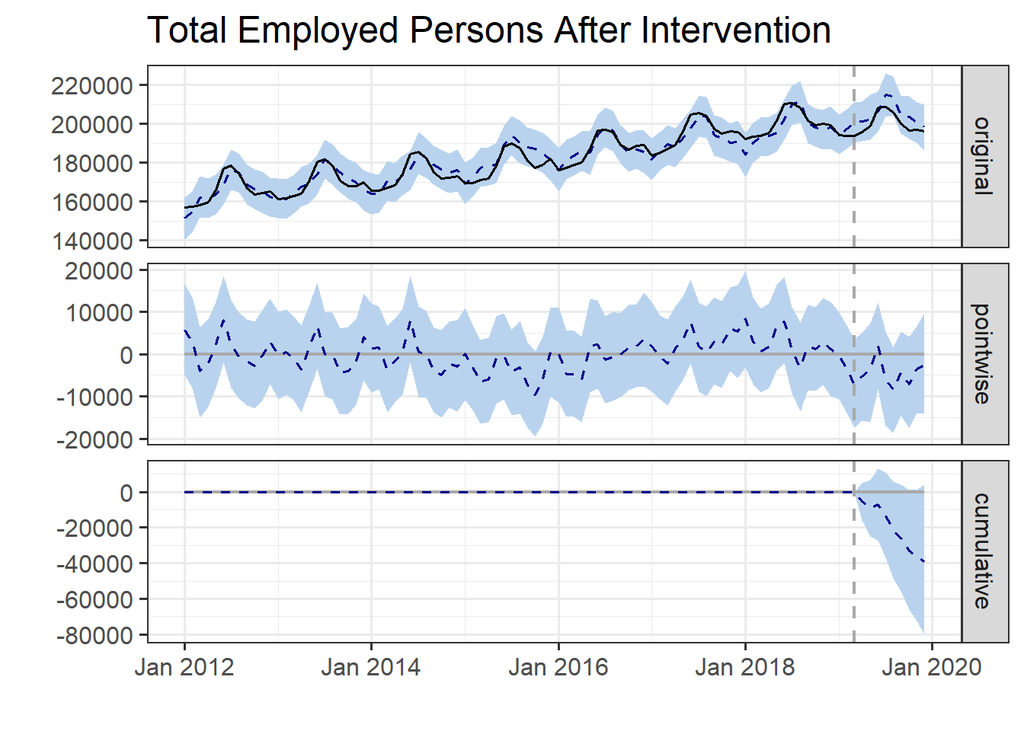

```r
# changed this to use registered
complete <- month # Restart the formula
# what is the selected indicator's column?
complete2 <- complete[,67] # change this to pick out your indicator, then just pick your dates
# list of remaining columns
icelandcolumns <- grep('iceland', colnames(complete))
complete <- complete[,-c(icelandcolumns)]

complete <- cbind(complete,complete2)

complete <- complete %>% filter(date > '2011-12-31') %>% filter(date < '2019-12-31') # to do arrivals
complete <- complete[ , colSums(is.na(complete))==0] %>% relocate(registered_employed_persons_iceland) %>% relocate(date)

impact_temp <- ts(data = complete[-c(1)],
                             start = 2012,
                             end = 2020,
                             frequency = 12) %>% head(-1) # need this on ALL of these


pre.period <- as.yearmon(c("2012-01-01", "2019-03-01"))

post.period <- as.yearmon(c("2019-04-01", "2019-12-31"))

impact_temp <- CausalImpact(impact_temp,pre.period, post.period, model.args=list(niter=5000))
plot(impact_temp) + ggtitle("Total Employed Persons After Intervention")
```

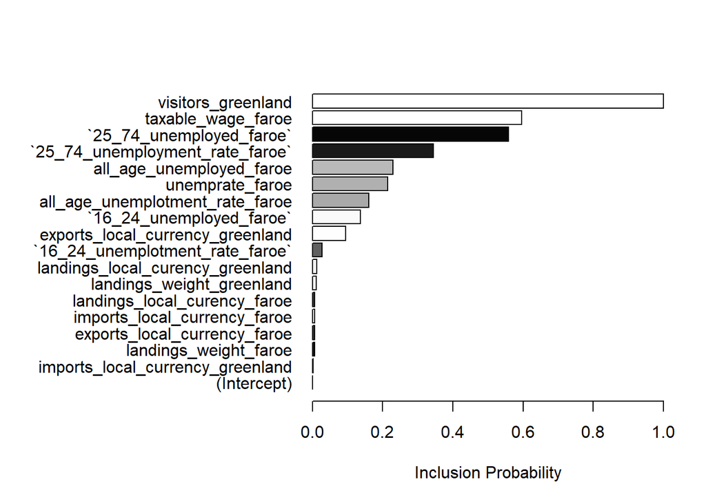

```r
plot(impact_temp$model$bsts.model, "coefficients") # predictors for Employment
```

```r
summary(impact_temp)
```

```
## Posterior inference {CausalImpact}
##
##                          Average            Cumulative
## Actual                   200856             1807700
## Prediction (s.d.)        205186 (2383)      1846674 (21451)
## 95% CI                   [200381, 209751]   [1803425, 1887761]
##
## Absolute effect (s.d.)   -4330 (2383)       -38974 (21451)
## 95% CI                   [-8896, 475]       [-80061, 4275]
##
## Relative effect (s.d.)   -2.1% (1.1%)       -2.1% (1.1%)
## 95% CI                   [-4.2%, 0.24%]     [-4.2%, 0.24%]
##
## Posterior tail-area probability p:   0.0364
## Posterior prob. of a causal effect:  96.36%
##
## For more details, type: summary(impact, "report")
```

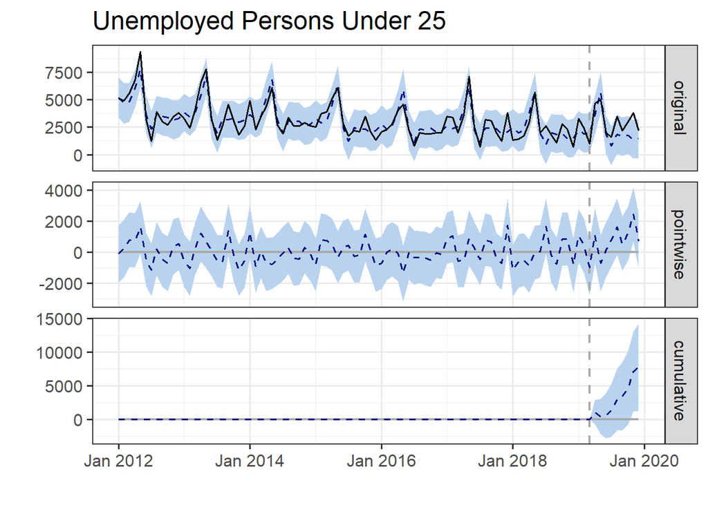

```r
complete <- month # Restart the formula
# what is the selected indicator's column?
complete2 <- complete[,85] # change this to pick out your indicator, then just pick your dates
colnames(complete2) <- c("under_25_unemployed_iceland")
# list of remaining columns
icelandcolumns <- grep('iceland', colnames(complete))
complete <- complete[,-c(icelandcolumns)]

complete <- cbind(complete,complete2)

complete <- complete %>% filter(date > '2011-12-31') %>% filter(date < '2019-12-31') # to do arrivals
complete <- complete[ , colSums(is.na(complete))==0] %>% relocate(under_25_unemployed_iceland) %>% relocate(date)

impact_temp <- ts(data = complete[-c(1)],
                             start = 2012,
                             end = 2020,
                             frequency = 12) %>% head(-1) # need this on ALL of these


pre.period <- as.yearmon(c("2012-01-01", "2019-03-01"))

post.period <- as.yearmon(c("2019-04-01", "2019-12-31"))

impact_temp <- CausalImpact(impact_temp,pre.period, post.period, model.args=list(niter=5000, nseasons = 12, season.duration = 1))
plot(impact_temp) + ggtitle("Unemployed Persons Under 25")
```

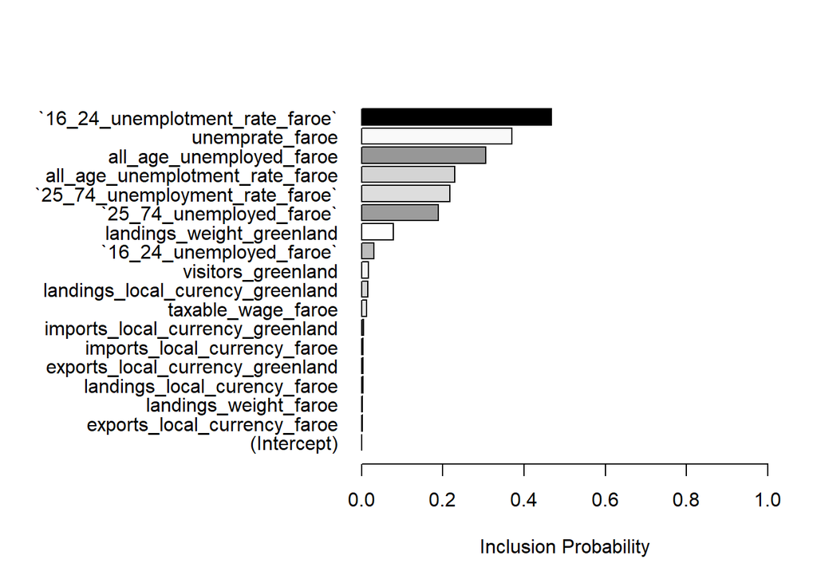

```r
plot(impact_temp$model$bsts.model, "coefficients") # predictors for Under 25 Unemployment
```

```r
summary(impact_temp)
```

```
## Posterior inference {CausalImpact}
##
##                          Average        Cumulative
## Actual                   3111           28000
## Prediction (s.d.)        2241 (363)     20166 (3269)
## 95% CI                   [1533, 2970]   [13800, 26727]
##
## Absolute effect (s.d.)   870 (363)      7834 (3269)
## 95% CI                   [141, 1578]    [1273, 14200]
##
## Relative effect (s.d.)   43% (25%)      43% (25%)
## 95% CI                   [4.8%, 103%]   [4.8%, 103%]
##
## Posterior tail-area probability p:   0.0092
## Posterior prob. of a causal effect:  99.08%
##
## For more details, type: summary(impact, "report")
```

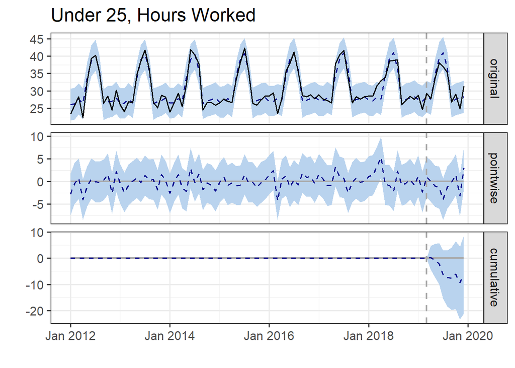

```r
complete <- month # Restart the formula
# what is the selected indicator's column?
complete2 <- complete[,94] # change this to pick out your indicator, then just pick your dates
colnames(complete2) <- c("Under_24_hours_worked_iceland")
# list of remaining columns
icelandcolumns <- grep('iceland', colnames(complete))
complete <- complete[,-c(icelandcolumns)]

complete <- cbind(complete,complete2)

complete <- complete %>% filter(date > '2011-12-31') %>% filter(date < '2019-12-31') # to do arrivals
complete <- complete[ , colSums(is.na(complete))==0] %>% relocate(Under_24_hours_worked_iceland) %>% relocate(date)

impact_temp <- ts(data = complete[-c(1)],
                             start = 2012,
                             end = 2020,
                             frequency = 12) %>% head(-1) # need this on ALL of these


pre.period <- as.yearmon(c("2012-01-01", "2019-03-01"))

post.period <- as.yearmon(c("2019-04-01", "2019-12-31"))

impact_temp <- CausalImpact(impact_temp,pre.period, post.period, model.args=list(niter=5000, nseasons = 12, season.duration = 1))
plot(impact_temp) +ggtitle("Under 25, Hours Worked")
```

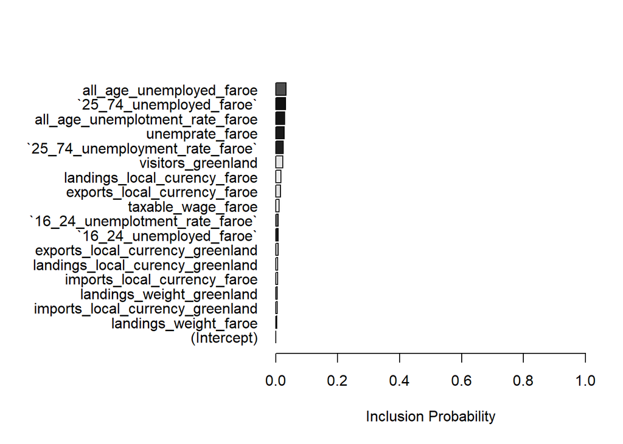

```r
plot(impact_temp$model$bsts.model, "coefficients") # predictors for Hours Worked
```

```r
summary(impact_temp)
```

```
## Posterior inference {CausalImpact}
##
##                          Average         Cumulative
## Actual                   32              284
## Prediction (s.d.)        32 (0.85)       290 (7.63)
## 95% CI                   [31, 34]        [275, 305]
##
## Absolute effect (s.d.)   -0.7 (0.85)     -6.3 (7.63)
## 95% CI                   [-2.3, 0.94]    [-21.1, 8.50]
##
## Relative effect (s.d.)   -2.1% (2.6%)    -2.1% (2.6%)
## 95% CI                   [-6.9%, 3.1%]   [-6.9%, 3.1%]
##
## Posterior tail-area probability p:   0.20624
## Posterior prob. of a causal effect:  79%
##
## For more details, type: summary(impact, "report")
```

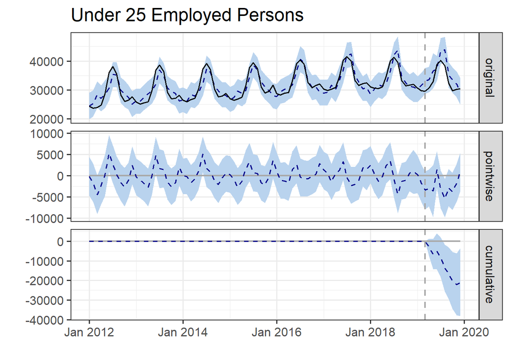

```r
# this is registered, not a survey
complete <- month # Restart the formula
# what is the selected indicator's column?
complete2 <- complete[,70] # change this to pick out your indicator, then just pick your dates
colnames(complete2) <- c("under_25_employed_iceland")
# list of remaining columns
icelandcolumns <- grep('iceland', colnames(complete))
complete <- complete[,-c(icelandcolumns)]

complete <- cbind(complete,complete2)

complete <- complete %>% filter(date > '2011-12-31') %>% filter(date < '2019-12-31') # to do arrivals
complete <- complete[ , colSums(is.na(complete))==0] %>% relocate(under_25_employed_iceland) %>% relocate(date)

impact_temp <- ts(data = complete[-c(1)],
                             start = 2012,
                             end = 2020,
                             frequency = 12) %>% head(-1) # need this on ALL of these


pre.period <- as.yearmon(c("2012-01-01", "2019-03-01"))

post.period <- as.yearmon(c("2019-04-01", "2019-12-31"))

impact_temp <- CausalImpact(impact_temp,pre.period, post.period, model.args=list(niter=5000))
plot(impact_temp) + ggtitle("Under 25 Employed Persons")
```

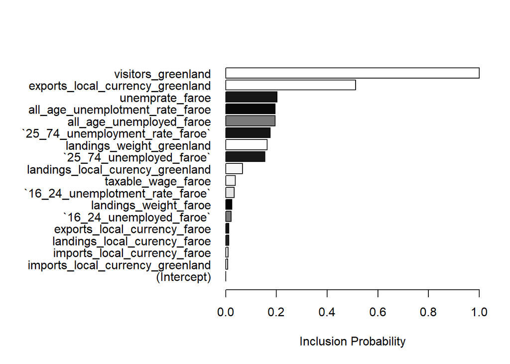

```r
plot(impact_temp$model$bsts.model, "coefficients") # predictors for Under 25 employment
```

```r
summary(impact_temp)
```

```
## Posterior inference {CausalImpact}
##
##                          Average          Cumulative
## Actual                   33757            303813
## Prediction (s.d.)        36102 (989)      324916 (8904)
## 95% CI                   [34150, 37992]   [307347, 341929]
##
## Absolute effect (s.d.)   -2345 (989)      -21103 (8904)
## 95% CI                   [-4235, -393]    [-38116, -3534]
##
## Relative effect (s.d.)   -6.4% (2.6%)     -6.4% (2.6%)
## 95% CI                   [-11%, -1.1%]    [-11%, -1.1%]
##
## Posterior tail-area probability p:   0.00962
## Posterior prob. of a causal effect:  99.03808%
##
## For more details, type: summary(impact, "report")
```

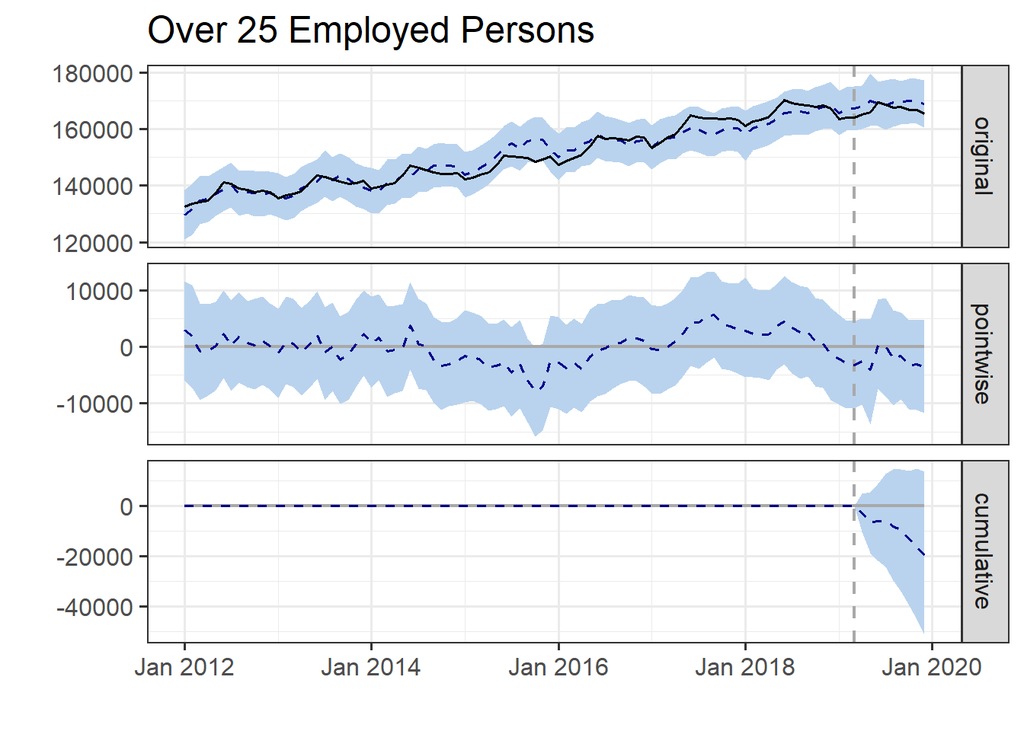

```r
# this is registered, not a survey
complete <- month # Restart the formula
# what is the selected indicator's column?
complete2 <- complete[,c(67)]- complete[,c(70)]  # change this to pick out your indicator, then just pick your dates
colnames(complete2) <- c("Over_25_employed_iceland")
# list of remaining columns
icelandcolumns <- grep('iceland', colnames(complete))
complete <- complete[,-c(icelandcolumns)]

complete <- cbind(complete,complete2)

complete <- complete %>% filter(date > '2011-12-31') %>% filter(date < '2019-12-31') # to do arrivals
complete <- complete[ , colSums(is.na(complete))==0] %>% relocate(Over_25_employed_iceland) %>% relocate(date)

impact_temp <- ts(data = complete[-c(1)],
                             start = 2012,
                             end = 2020,
                             frequency = 12) %>% head(-1) # need this on ALL of these


pre.period <- as.yearmon(c("2012-01-01", "2019-03-01"))

post.period <- as.yearmon(c("2019-04-01", "2019-12-31"))

impact_temp <- CausalImpact(impact_temp,pre.period, post.period, model.args=list(niter=5000))
plot(impact_temp) + ggtitle("Over 25 Employed Persons")
```

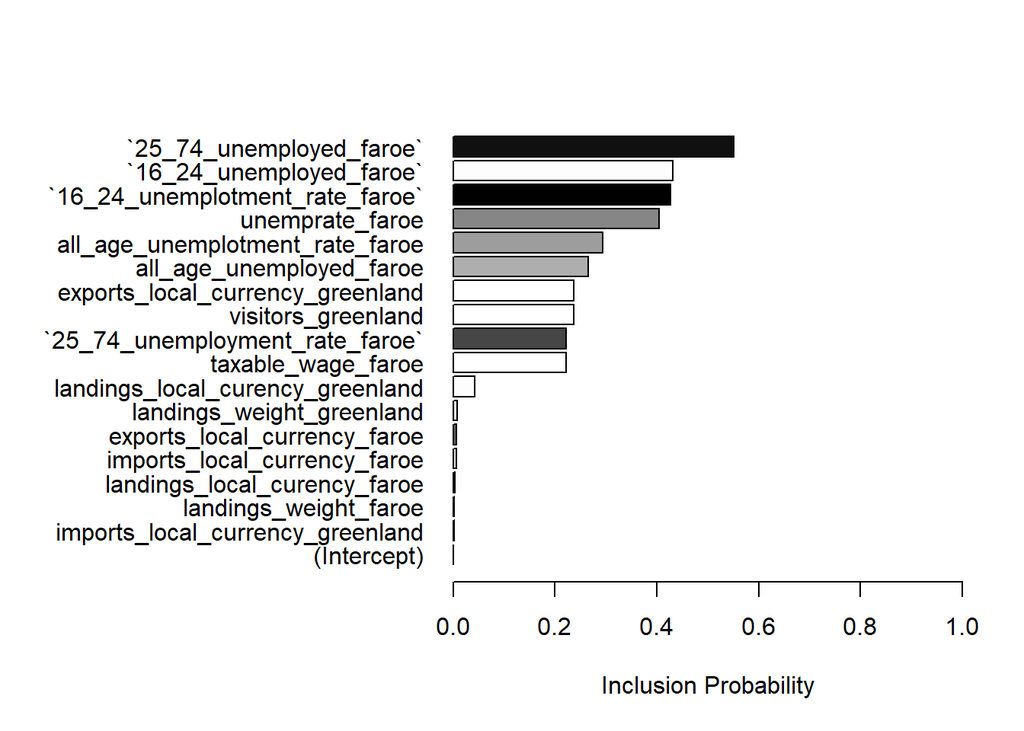

```r
plot(impact_temp$model$bsts.model, "coefficients") # predictors for Under 25 employment
```

```r
summary(impact_temp)
```

```
## Posterior inference {CausalImpact}
##
##                          Average            Cumulative
## Actual                   167099             1503887
## Prediction (s.d.)        169275 (1807)      1523477 (16260)
## 95% CI                   [165563, 172789]   [1490067, 1555097]
##
## Absolute effect (s.d.)   -2177 (1807)       -19590 (16260)
## 95% CI                   [-5690, 1536]      [-51210, 13820]
##
## Relative effect (s.d.)   -1.3% (1.1%)       -1.3% (1.1%)
## 95% CI                   [-3.3%, 0.93%]     [-3.3%, 0.93%]
##
## Posterior tail-area probability p:   0.11872
## Posterior prob. of a causal effect:  88%
##
## For more details, type: summary(impact, "report")
```

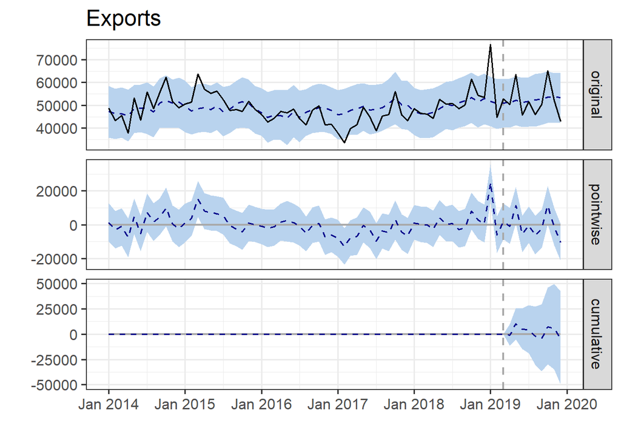

```r
complete <- month # Restart the formula
# what is the selected indicator's column?
complete2 <- complete[,55] # change this to pick out your indicator, then just pick your dates
# list of remaining columns
icelandcolumns <- grep('iceland', colnames(complete))
complete <- complete[,-c(icelandcolumns)]

complete <- cbind(complete,complete2)

complete <- complete %>% filter(date > '2013-12-31') %>% filter(date < '2019-12-31') # to do arrivals
complete <- complete[ , colSums(is.na(complete))==0] %>% relocate(exports_local_currency_iceland) %>% relocate(date)

impact_temp <- ts(data = complete[-c(1)],
                             start = 2014,
                             end = 2020,
                             frequency = 12) %>% head(-1) # need this on ALL of these


pre.period <- as.yearmon(c("2014-01-01", "2019-03-01"))

post.period <- as.yearmon(c("2019-04-01", "2019-12-31"))

impact_temp <- CausalImpact(impact_temp,pre.period, post.period, model.args=list(niter=5000))
plot(impact_temp) + ggtitle("Exports")
```

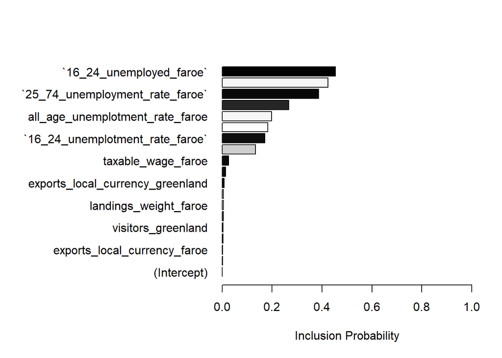

```r
plot(impact_temp$model$bsts.model, "coefficients") # predictors for over 25 employment
```